# HW 1.1

Davis Vaughan

1/12/2018

## Load required packages

If you want to run the code, you will need the packages below. To install them you would have to do the code that is commented out. If you have any questions, let me know!

```r
library(dplyr)
library(lubridate)
library(tidyquant)
options(pillar.sigfig = 6)

# To install the above packages if you don't have them:
# install.packages("dplyr")
# install.packages("lubridate")
# install.packages("devtools")
# devtools::install_github("business-science/tidyquant")
```

## Initialize variables

```r
# 100 shares of SPY
shares_spy <- 100

# 400 European put options on Apple
options_appl   <- 400
time_to_expiry <- 1
sigma          <- .25    # volatility
k              <- 114    # strike
r              <- .012   # risk free int rate
y              <- .019   # div yield

# Dates
end_date   <- as.Date("2017-01-06")
start_date <- end_date - years(2) + days(2) # Add two days to get the correct 504 prices
```

## Retrieve data

Based on the HW notes, “most recent AAPL price of 117.91” implies that he used closing prices, because that is the only one that fits.

```r
spy  <- tq_get("SPY",  from = start_date, to = end_date, get = "stock.prices.google") %>%
  select(date, close) %>%
  rename(spy_close = close)

spy
```

```
## # A tibble: 504 x 2
##    date       spy_close
##    <date>         <dbl>
##  1 2015-01-08    205.90
##  2 2015-01-09    204.25
##  3 2015-01-12    202.65
##  4 2015-01-13    202.08
##  5 2015-01-14    200.86
##  6 2015-01-15    199.02
##  7 2015-01-16    201.63
##  8 2015-01-20    202.06
##  9 2015-01-21    203.08
## 10 2015-01-22    206.10
## # ... with 494 more rows
```

```r
aapl <- tq_get("AAPL", from = start_date, to = end_date, get = "stock.prices.google") %>%
  select(date, close)

aapl
```

```
## # A tibble: 504 x 2
##    date        close
##    <date>      <dbl>
##  1 2015-01-08 111.89
##  2 2015-01-09 112.01
##  3 2015-01-12 109.25
##  4 2015-01-13 110.22
##  5 2015-01-14 109.80
##  6 2015-01-15 106.82
##  7 2015-01-16 105.99
##  8 2015-01-20 108.72
##  9 2015-01-21 109.55
## 10 2015-01-22 112.40
## # ... with 494 more rows
```

## Black scholes pricing function

```r
put_option_pricer <- function(s, k, r, y, t, sigma) {

  d1 <- (log(s / k) + (r - y + sigma^2 / 2) * t) / (sigma * sqrt(t))
  d2 <- d1 - sigma * sqrt(t)

  V <- pnorm(-d2) * k * exp(-r * t) - s * exp(-y * t) * pnorm(-d1)

  V
}
```

## ECDF plotting function

```r
plot_ecdf <- function(x, which_approx) {
  ggplot(x, aes(x = portf_delta_p)) +
  stat_ecdf(geom = "step", size = .8) +
  geom_hline(yintercept = 1, linetype = "dashed") +
  geom_hline(yintercept = 0, linetype = "dashed") +
  geom_vline(xintercept = sort(x$portf_delta_p)[percentile_99], linetype = "dashed") +
  theme_minimal() +
  labs(x = "Loss (Negative = worse)", y = "ECDF",
       title = "ECDF of the loss distribution. Vertical line marks VaR.",
       subtitle = which_approx)
}
```

## VaR weighted sorter

`join_and_weight()` will join the Apple and SPY delta_p’s together, weighted appropriately.

`summarise_VaR()` will calculate the VaR from the portfolio delta_p values.

```r
join_and_weight <- function(aapl, spy, options_aapl, shares_spy) {
  aapl %>%
    left_join(spy, "date") %>%
    mutate(portf_delta_p = shares_spy * spy_delta_p + options_aapl * delta_p) %>%
    na.omit()
}

summarise_VaR <- function(portfolio, percentile) {
  portfolio %>%
    summarise(VaR = sort(portf_delta_p)[percentile])
}
```

## More setup

We have to calculate the 99th percentile value for VaR. There are multiple ways to calculate a quantile, let’s just use a simple way of taking 1% of the total number of differences we have (503) and rounding down. This gives us 5, a more conservative estimate than is required if we were allowed to interpolate.

```r
# 99th percentile on 503 values
percentile_99 <- round((nrow(aapl) - 1) * 0.01)

percentile_99
```

```
## [1] 5
```

We have to calculate the 97th percentile value for ES.

```r
# 97th percentile on 503 values
percentile_97 <- round((nrow(aapl) - 1) * 0.03)

percentile_97
```

```
## [1] 15
```

Also important are the current value of Apple and SPY. And the current value of the put option on Apple.

```r
# Current value of AAPL and SPY
current_close_aapl <- last(aapl$close)
current_close_aapl
```

```
## [1] 117.91
```

```r
current_close_spy  <- last(spy$spy_close)
current_close_spy
```

```
## [1] 227.21
```

```r
# Current put option value of AAPL
current_option_value <- put_option_pricer(current_close_aapl, k , r, y, time_to_expiry, sigma)
current_option_value
```

```
## [1] 9.895917
```

## Calculate relative and absolute differences

Go ahead and calculate separate data frames for relative and absolute differences of Apple and SPY. These will be useful to us later.

For SPY, calculating the deltaX values (relative and absolute shifts) is the same as calculing the deltaP values of a single share of SPY. For Apple, we need to also estimate the shifted option value price, which is what most of this HW is about.

```r
# Apple relative and absolute shifts
aapl_rel <- aapl %>%
  mutate(daily_return = close / lag(close) - 1,
         delta_close  = daily_return * current_close_aapl)

aapl_rel
```

```
## # A tibble: 504 x 4
##    date        close daily_return delta_close
##    <date>      <dbl>        <dbl>       <dbl>
##  1 2015-01-08 111.89  NA            NA
##  2 2015-01-09 112.01   0.00107248    0.126456
##  3 2015-01-12 109.25 - 0.0246407   - 2.90538
##  4 2015-01-13 110.22   0.00887872    1.04689
##  5 2015-01-14 109.80 - 0.00381056  - 0.449303
##  6 2015-01-15 106.82 - 0.0271403   - 3.20011
##  7 2015-01-16 105.99 - 0.00777008  - 0.916170
##  8 2015-01-20 108.72   0.0257571     3.03703
##  9 2015-01-21 109.55   0.00763429    0.900159
## 10 2015-01-22 112.40   0.0260155     3.06749
## # ... with 494 more rows
```

```r
aapl_abs <- aapl %>%
  mutate(delta_close = close - lag(close))

aapl_abs
```

```
## # A tibble: 504 x 3
##    date        close delta_close
##    <date>      <dbl>       <dbl>
##  1 2015-01-08 111.89   NA
##  2 2015-01-09 112.01    0.120000
##  3 2015-01-12 109.25  - 2.76000
##  4 2015-01-13 110.22    0.970000
##  5 2015-01-14 109.80  - 0.420000
##  6 2015-01-15 106.82  - 2.98000
##  7 2015-01-16 105.99  - 0.830000
##  8 2015-01-20 108.72    2.73000
##  9 2015-01-21 109.55    0.830000
## 10 2015-01-22 112.40    2.85000
## # ... with 494 more rows
```

```r
# Spy relative and absolute shifts
# For SPY, the shifts (delta_x) are the delta_p values
spy_rel <- spy %>%
  mutate(spy_delta_p  = (spy_close / lag(spy_close) - 1) * current_close_spy)

spy_rel
```

```
## # A tibble: 504 x 3
##    date       spy_close spy_delta_p
##    <date>         <dbl>       <dbl>
##  1 2015-01-08    205.90   NA
##  2 2015-01-09    204.25  - 1.82077
##  3 2015-01-12    202.65  - 1.77986
##  4 2015-01-13    202.08  - 0.639081
##  5 2015-01-14    200.86  - 1.37172
##  6 2015-01-15    199.02  - 2.08138
##  7 2015-01-16    201.63    2.97969
##  8 2015-01-20    202.06    0.484552
##  9 2015-01-21    203.08    1.14696
## 10 2015-01-22    206.10    3.37884
## # ... with 494 more rows
```

```r
spy_abs <- spy %>%
  mutate(spy_delta_p = spy_close - lag(spy_close))

spy_abs
```

```
## # A tibble: 504 x 3
##    date       spy_close spy_delta_p
##    <date>         <dbl>       <dbl>
##  1 2015-01-08    205.90   NA
##  2 2015-01-09    204.25  - 1.65000
##  3 2015-01-12    202.65  - 1.60000
##  4 2015-01-13    202.08  - 0.570000
##  5 2015-01-14    200.86  - 1.22000
##  6 2015-01-15    199.02  - 1.84000
##  7 2015-01-16    201.63    2.61000
##  8 2015-01-20    202.06    0.430000
##  9 2015-01-21    203.08    1.02000
## 10 2015-01-22    206.10    3.02000
## # ... with 494 more rows
```

## 1a - Delta gamma approx, Analytical, Absolute shifts

Use analytical delta and gamma to calculate deltaP for Apple options.

```r
# Required for delta/gamma analytical
d1 <- (log(current_close_aapl / k) + (r - y + sigma^2 / 2) * time_to_expiry) / (sigma * sqrt(time_to_expiry))

# Put delta and gamma
delta_analytical <- exp(-y * time_to_expiry) * (pnorm(d1) - 1)
delta_analytical
```

```
## [1] -0.400626
```

```r
gamma_numerator   <- exp(-y * time_to_expiry) * exp(- (d1 ^ 2) / 2)
gamma_denominator <- current_close_aapl * sigma * sqrt(time_to_expiry) * sqrt(2 * pi)

gamma_analytical <- gamma_numerator / gamma_denominator
gamma_analytical
```

```
## [1] 0.0129268
```

```r
# Apple DG analytical approx with absolute shifts
aapl_abs_dg_analytical <- aapl_abs %>%
  mutate(delta_p =  delta_analytical * delta_close + 1/2 * gamma_analytical * delta_close ^ 2)

aapl_abs_dg_analytical
```

```
## # A tibble: 504 x 4
##    date        close delta_close     delta_p
##    <date>      <dbl>       <dbl>       <dbl>
##  1 2015-01-08 111.89   NA         NA
##  2 2015-01-09 112.01    0.120000 - 0.0479820
##  3 2015-01-12 109.25  - 2.76000    1.15496
##  4 2015-01-13 110.22    0.970000 - 0.382526
##  5 2015-01-14 109.80  - 0.420000   0.169403
##  6 2015-01-15 106.82  - 2.98000    1.25126
##  7 2015-01-16 105.99  - 0.830000   0.336972
##  8 2015-01-20 108.72    2.73000  - 1.04554
##  9 2015-01-21 109.55    0.830000 - 0.328067
## 10 2015-01-22 112.40    2.85000  - 1.08929
## # ... with 494 more rows
```

Now weight and combine the Apple deltaP and SPY deltaP to get portfolio deltaP.

```r
portf_abs_dg_analytical <- join_and_weight(aapl_abs_dg_analytical, spy_abs, options_appl, shares_spy)
select(portf_abs_dg_analytical, date, portf_delta_p)
```

```
## # A tibble: 503 x 2
##    date       portf_delta_p
##    <date>             <dbl>
##  1 2015-01-09     -184.19
##  2 2015-01-12      301.99
##  3 2015-01-13     -210.01
##  4 2015-01-14     - 54.2388
##  5 2015-01-15      316.50
##  6 2015-01-16      395.79
##  7 2015-01-20     -375.21
##  8 2015-01-21     - 29.2268
##  9 2015-01-22     -133.71
## 10 2015-01-23     -205.08
## # ... with 493 more rows
```

Sort and take the 5th worst value (corresponds to 99% percentile) to get VaR.

```r
# Portfolio VaR
summarise_VaR(portf_abs_dg_analytical, percentile_99)
```

```
## # A tibble: 1 x 1
##       VaR
##     <dbl>
## 1 -532.21
```

Also add a plot of the ECDF

Every plot of the ECDF looks like this one, so I will only show just this one.

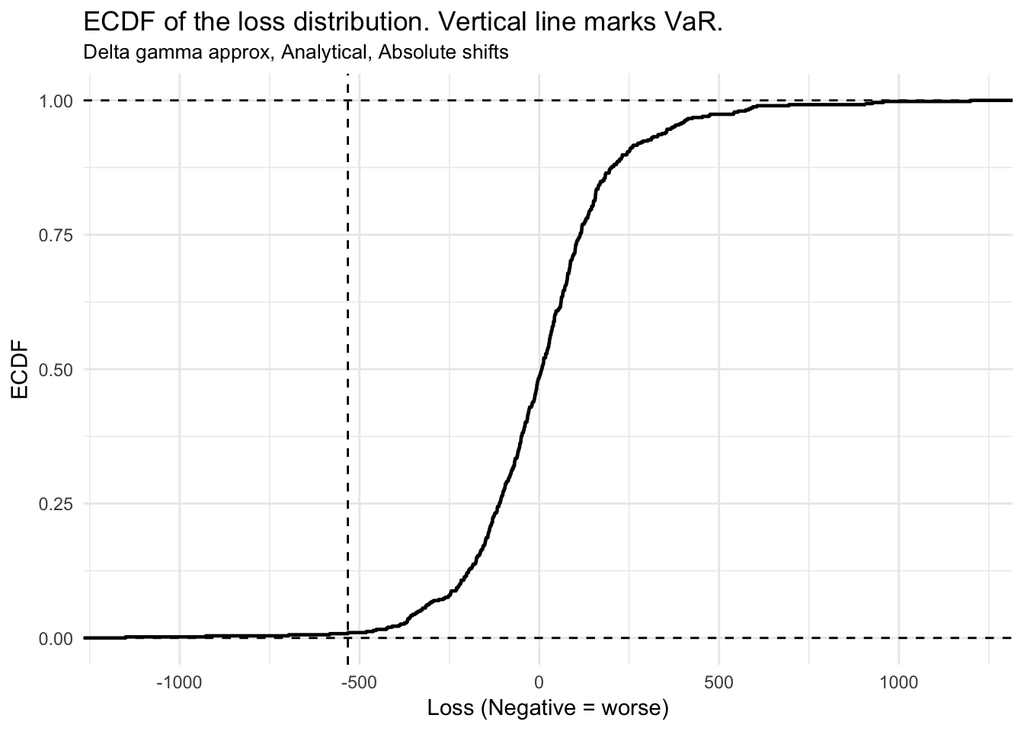

```r
plot_ecdf(portf_abs_dg_analytical, "Delta gamma approx, Analytical, Absolute shifts")
```

## 1b - Delta gamma approx, Numerical, Absolute shifts

For Apple options, rather than using Black scholes delta/gamma, let’s approximate them using the central difference estimators we talked about in class.

```r
aapl_abs_dg_numerical <- aapl_abs %>%
  na.omit() %>%
  mutate(

    # Calculate h for absolute
    h                = sqrt(var(delta_close) + mean(delta_close) ^ 2),

    # Recalculate the put options with a shock upward
    shift_up_close   = put_option_pricer(current_close_aapl + h, k, r, y, time_to_expiry, sigma),

    # Recalculate the put options with a shock downward
    shift_down_close = put_option_pricer(current_close_aapl - h, k, r, y, time_to_expiry, sigma),

    # This is P in the formula, used by gamma
    no_shift_close   = put_option_pricer(current_close_aapl, k, r, y, time_to_expiry, sigma),

    # Approximate delta
    delta_numerical  = (shift_up_close - shift_down_close) / (2 * h),

    # Approximate gamma
    gamma_numerical  = (shift_up_close - 2 * no_shift_close + shift_down_close) / (h^2),

    # Calculate delta_p from numerical delta/gamma
    delta_p          = delta_numerical * delta_close + 1/2 * gamma_numerical * delta_close ^ 2
  )

# This is h
aapl_abs_dg_numerical$h[1]
```

```
## [1] 1.733868
```

```r
# Here are the shifts
select(aapl_abs_dg_numerical, date, contains("shift"))
```

```
## # A tibble: 503 x 4
##    date       shift_up_close shift_down_close no_shift_close
##    <date>              <dbl>            <dbl>          <dbl>
##  1 2015-01-09        9.22053          10.6102        9.89592
##  2 2015-01-12        9.22053          10.6102        9.89592
##  3 2015-01-13        9.22053          10.6102        9.89592
##  4 2015-01-14        9.22053          10.6102        9.89592
##  5 2015-01-15        9.22053          10.6102        9.89592
##  6 2015-01-16        9.22053          10.6102        9.89592
##  7 2015-01-20        9.22053          10.6102        9.89592
##  8 2015-01-21        9.22053          10.6102        9.89592
##  9 2015-01-22        9.22053          10.6102        9.89592
## 10 2015-01-23        9.22053          10.6102        9.89592
## # ... with 493 more rows
```

```r
# Here is delta / gamma  / delta_p
select(aapl_abs_dg_numerical, date, delta_numerical, gamma_numerical, delta_p)
```

```
## # A tibble: 503 x 4
##    date       delta_numerical gamma_numerical    delta_p
##    <date>               <dbl>           <dbl>      <dbl>
##  1 2015-01-09       -0.400732       0.0129244 -0.0479948
##  2 2015-01-12       -0.400732       0.0129244  1.15525
##  3 2015-01-13       -0.400732       0.0129244 -0.382630
##  4 2015-01-14       -0.400732       0.0129244  0.169447
##  5 2015-01-15       -0.400732       0.0129244  1.25157
##  6 2015-01-16       -0.400732       0.0129244  0.337059
##  7 2015-01-20       -0.400732       0.0129244 -1.04584
##  8 2015-01-21       -0.400732       0.0129244 -0.328156
##  9 2015-01-22       -0.400732       0.0129244 -1.08960
## 10 2015-01-23       -0.400732       0.0129244 -0.230251
## # ... with 493 more rows
```

Now weight and combine the Apple deltaP and SPY deltaP to get portfolio deltaP.

```r
portf_abs_dg_numerical <- join_and_weight(aapl_abs_dg_numerical, spy_abs, options_appl, shares_spy)
select(portf_abs_dg_numerical, date, portf_delta_p)
```

```
## # A tibble: 503 x 2
##    date       portf_delta_p
##    <date>             <dbl>
##  1 2015-01-09     -184.20
##  2 2015-01-12      302.10
##  3 2015-01-13     -210.05
##  4 2015-01-14     - 54.2211
##  5 2015-01-15      316.63
##  6 2015-01-16      395.82
##  7 2015-01-20     -375.33
##  8 2015-01-21     - 29.2622
##  9 2015-01-22     -133.84
## 10 2015-01-23     -205.10
## # ... with 493 more rows
```

Portfolio VaR

```r
summarise_VaR(portf_abs_dg_numerical, percentile_99)
```

```
## # A tibble: 1 x 1
##       VaR
##     <dbl>
## 1 -532.36
```

## 1c - Grid approx, Absolute

The `approx()` function below uses linear interpolation by default.

There is no need to do a grid for SPY. For Apple, we needed to approximate the relationship between a shift in the underlying and a shift in the value of the option. We don’t have to do that with SPY since we are directly holding shares of it.

The approximation done below is done with `x = Apple prices` and `y = Apple option values` so that we can pass in shifted Apple prices, with the shifts being either absolute or relative.

```r
grid_multipliers <- c(.6, .7, .8, .9, .95, .99, 1, 1.01, 1.05, 1.1, 1.2, 1.3, 1.4)
grid_prices      <- grid_multipliers * current_close_aapl
grid_options     <- put_option_pricer(grid_prices, k, r, y, time_to_expiry, sigma)

aapl_abs_grid <- aapl_abs %>%
  na.omit() %>%
  mutate(
    shifted_current_close       = delta_close + current_close_aapl,
    approx_shifted_option_value = approx(x = grid_prices, y = grid_options, xout = shifted_current_close)$y,
    delta_p                     = approx_shifted_option_value - current_option_value
  )

select(aapl_abs_grid, -close, -delta_close)
```

```
## # A tibble: 503 x 4
##    date       shifted_current_close approx_shifted_option_value    delta_p
##    <date>                     <dbl>                       <dbl>      <dbl>
##  1 2015-01-09                118.03                     9.84875 -0.0471666
##  2 2015-01-12                115.15                    11.0852   1.18928
##  3 2015-01-13                118.88                     9.51465 -0.381263
##  4 2015-01-14                117.49                    10.0674   0.171484
##  5 2015-01-15                114.93                    11.1837   1.28778
##  6 2015-01-16                117.08                    10.2348   0.338885
##  7 2015-01-20                120.64                     8.87956 -1.01636
##  8 2015-01-21                118.74                     9.56968 -0.326235
##  9 2015-01-22                120.76                     8.83678 -1.05914
## 10 2015-01-23                118.49                     9.66795 -0.227972
## # ... with 493 more rows
```

```r
portf_abs_grid <- join_and_weight(aapl_abs_grid, spy_abs, options_appl, shares_spy)
select(portf_abs_grid, date, portf_delta_p)
```

```
## # A tibble: 503 x 2
##    date       portf_delta_p
##    <date>             <dbl>
##  1 2015-01-09     -183.87
##  2 2015-01-12      315.71
##  3 2015-01-13     -209.50
##  4 2015-01-14     - 53.4064
##  5 2015-01-15      331.11
##  6 2015-01-16      396.55
##  7 2015-01-20     -363.54
##  8 2015-01-21     - 28.4941
##  9 2015-01-22     -121.66
## 10 2015-01-23     -204.19
## # ... with 493 more rows
```

```r
summarise_VaR(portf_abs_grid, percentile_99)
```

```
## # A tibble: 1 x 1
##       VaR
##     <dbl>
## 1 -519.35
```

## 1d - Full reeval, Absolute

This time we do a full reevaluation. Shift the current close price of Apple forward 1 day by using the historical absolute shifts, and then revalue the option. The difference between the current option price and the shifted option prices is your column of delta_p’s.

```r
aapl_abs_full_reeval <- aapl_abs %>%
  mutate(shifted_current_close = current_close_aapl + delta_close,
         shifted_option_value  = put_option_pricer(shifted_current_close, k, r, y, time_to_expiry, sigma),
         delta_p               = shifted_option_value - current_option_value)

select(aapl_abs_full_reeval, -close, -delta_close)
```

```
## # A tibble: 504 x 4
##    date       shifted_current_close shifted_option_value     delta_p
##    <date>                     <dbl>                <dbl>       <dbl>
##  1 2015-01-08                 NA                NA        NA
##  2 2015-01-09                118.03              9.84793 - 0.0479821
##  3 2015-01-12                115.15             11.0516    1.15568
##  4 2015-01-13                118.88              9.51336 - 0.382558
##  5 2015-01-14                117.49             10.0653    0.169406
##  6 2015-01-15                114.93             11.1481    1.25216
##  7 2015-01-16                117.08             10.2329    0.336992
##  8 2015-01-20                120.64              8.84964 - 1.04628
##  9 2015-01-21                118.74              9.56783 - 0.328087
## 10 2015-01-22                120.76              8.80579 - 1.09013
## # ... with 494 more rows
```

```r
portf_abs_full_reeval <- join_and_weight(aapl_abs_full_reeval, spy_abs, options_appl, shares_spy)
select(portf_abs_full_reeval, date, portf_delta_p)
```

```
## # A tibble: 503 x 2
##    date       portf_delta_p
##    <date>             <dbl>
##  1 2015-01-09     -184.19
##  2 2015-01-12      302.27
##  3 2015-01-13     -210.02
##  4 2015-01-14     - 54.2377
##  5 2015-01-15      316.87
##  6 2015-01-16      395.80
##  7 2015-01-20     -375.51
##  8 2015-01-21     - 29.2349
##  9 2015-01-22     -134.05
## 10 2015-01-23     -205.08
## # ... with 493 more rows
```

```r
summarise_VaR(portf_abs_full_reeval, percentile_99)
```

```
## # A tibble: 1 x 1
##       VaR
##     <dbl>
## 1 -532.83
```

## 1e - Delta gamma approx, Analytical, Relative shifts

```r
# Apple DG approx of delta_p
aapl_rel_dg_analytical <- aapl_rel %>%
  mutate(delta_p =  delta_analytical * delta_close + 1/2 * gamma_analytical * delta_close ^ 2)
```

Now weight and combine the Apple deltaP and SPY deltaP to get portfolio deltaP.

```r
portf_rel_dg_analytical <- join_and_weight(aapl_rel_dg_analytical, spy_rel, options_appl, shares_spy)
select(portf_rel_dg_analytical, date, portf_delta_p)
```

```
## # A tibble: 503 x 2
##    date       portf_delta_p
##    <date>             <dbl>
##  1 2015-01-09     -202.30
##  2 2015-01-12      309.43
##  3 2015-01-13     -228.84
##  4 2015-01-14     - 64.6486
##  5 2015-01-15      331.16
##  6 2015-01-16      446.96
##  7 2015-01-20     -414.38
##  8 2015-01-21     - 27.4602
##  9 2015-01-22     -129.36
## 10 2015-01-23     -221.12
## # ... with 493 more rows
```

```r
# Portfolio VaR
summarise_VaR(portf_rel_dg_analytical, percentile_99)
```

```
## # A tibble: 1 x 1
##       VaR
##     <dbl>
## 1 -524.75
```

## 1f - Delta gamma approx, Numerical, Relative shifts

```r
aapl_rel_dg_numerical <- aapl_rel %>%
  na.omit() %>%
  mutate(

    # Calculate h for absolute
    h                = sqrt(var(delta_close / close) + mean(delta_close / close) ^ 2),

    # Recalculate the put options with a shock upward
    shift_up_close   = put_option_pricer(current_close_aapl + h * current_close_aapl, k, r, y, time_to_expiry, sigma),

    # Recalculate the put options with a shock downward
    shift_down_close = put_option_pricer(current_close_aapl - h * current_close_aapl, k, r, y, time_to_expiry, sigma),

    # This is P in the formula, used by gamma
    no_shift_close   = put_option_pricer(current_close_aapl, k, r, y, time_to_expiry, sigma),

    # Approximate delta
    delta_numerical  = (shift_up_close - shift_down_close) / (2 * h * current_close_aapl),

    # Approximate gamma
    gamma_numerical  = (shift_up_close - 2 * no_shift_close + shift_down_close) / ((h * current_close_aapl)^2),

    # Calculate delta_p from numerical delta/gamma
    delta_p          = delta_numerical * delta_close + 1/2 * gamma_numerical * delta_close ^ 2
  )

# This is h
aapl_rel_dg_numerical$h[1]
```

```
## [1] 0.01702135
```

```r
# Here are the shifts
select(aapl_rel_dg_numerical, date, contains("shift"))
```

```
## # A tibble: 503 x 4
##    date       shift_up_close shift_down_close no_shift_close
##    <date>              <dbl>            <dbl>          <dbl>
##  1 2015-01-09        9.11761          10.7263        9.89592
##  2 2015-01-12        9.11761          10.7263        9.89592
##  3 2015-01-13        9.11761          10.7263        9.89592
##  4 2015-01-14        9.11761          10.7263        9.89592
##  5 2015-01-15        9.11761          10.7263        9.89592
##  6 2015-01-16        9.11761          10.7263        9.89592
##  7 2015-01-20        9.11761          10.7263        9.89592
##  8 2015-01-21        9.11761          10.7263        9.89592
##  9 2015-01-22        9.11761          10.7263        9.89592
## 10 2015-01-23        9.11761          10.7263        9.89592
## # ... with 493 more rows
```

```r
# Here is delta / gamma  / delta_p
select(aapl_rel_dg_numerical, date, delta_numerical, gamma_numerical, delta_p)
```

```
## # A tibble: 503 x 4
##    date       delta_numerical gamma_numerical    delta_p
##    <date>               <dbl>           <dbl>      <dbl>
##  1 2015-01-09       -0.400768       0.0129236 -0.0505763
##  2 2015-01-12       -0.400768       0.0129236  1.21893
##  3 2015-01-13       -0.400768       0.0129236 -0.412478
##  4 2015-01-14       -0.400768       0.0129236  0.181371
##  5 2015-01-15       -0.400768       0.0129236  1.34867
##  6 2015-01-16       -0.400768       0.0129236  0.372595
##  7 2015-01-20       -0.400768       0.0129236 -1.15754
##  8 2015-01-21       -0.400768       0.0129236 -0.355519
##  9 2015-01-22       -0.400768       0.0129236 -1.16855
## 10 2015-01-23       -0.400768       0.0129236 -0.241448
## # ... with 493 more rows
```

```r
portf_rel_dg_numerical <- join_and_weight(aapl_rel_dg_numerical, spy_rel, options_appl, shares_spy)
select(portf_rel_dg_numerical, date, portf_delta_p)
```

```
## # A tibble: 503 x 2
##    date       portf_delta_p
##    <date>             <dbl>
##  1 2015-01-09     -202.31
##  2 2015-01-12      309.58
##  3 2015-01-13     -228.90
##  4 2015-01-14     - 64.6232
##  5 2015-01-15      331.33
##  6 2015-01-16      447.01
##  7 2015-01-20     -414.56
##  8 2015-01-21     - 27.5118
##  9 2015-01-22     -129.54
## 10 2015-01-23     -221.15
## # ... with 493 more rows
```

Portfolio VaR

```r
summarise_VaR(portf_rel_dg_numerical, percentile_99)
```

```
## # A tibble: 1 x 1
##       VaR
##     <dbl>
## 1 -524.93
```

```r
grid_multipliers <- c(.6, .7, .8, .9, .95, 1, 1.01, 1.05, 1.1, 1.2, 1.3, 1.4)
grid_prices      <- grid_multipliers * current_close_aapl
grid_options     <- put_option_pricer(grid_prices, k, r, y, time_to_expiry, sigma)

aapl_rel_grid <- aapl_rel %>%
  na.omit() %>%
  mutate(
    shifted_current_close       = delta_close + current_close_aapl,
    approx_shifted_option_value = approx(x = grid_prices, y = grid_options, xout = shifted_current_close)$y,
    delta_p                     = approx_shifted_option_value - current_option_value
  )

select(aapl_rel_grid, -close, -daily_return, -delta_close)
```

```
## # A tibble: 503 x 4
##    date       shifted_current_close approx_shifted_option_value    delta_p
##    <date>                     <dbl>                       <dbl>      <dbl>
##  1 2015-01-09                118.04                     9.84621 -0.0497043
##  2 2015-01-12                115.00                    11.1739   1.27797
##  3 2015-01-13                118.96                     9.48443 -0.411485
##  4 2015-01-14                117.46                    10.0935   0.197632
##  5 2015-01-15                114.71                    11.3035   1.40761
##  6 2015-01-16                116.99                    10.2989   0.402990
##  7 2015-01-20                120.95                     8.77010 -1.12582
##  8 2015-01-21                118.81                     9.54211 -0.353812
##  9 2015-01-22                120.98                     8.75924 -1.13668
## 10 2015-01-23                118.52                     9.65677 -0.239147
## # ... with 493 more rows
```

```r
portf_rel_grid <- join_and_weight(aapl_rel_grid, spy_abs, options_appl, shares_spy)
select(portf_rel_grid, date, portf_delta_p)
```

```
## # A tibble: 503 x 2
##    date       portf_delta_p
##    <date>             <dbl>
##  1 2015-01-09     -184.88
##  2 2015-01-12      351.19
##  3 2015-01-13     -221.59
##  4 2015-01-14     - 42.9472
##  5 2015-01-15      379.04
##  6 2015-01-16      422.20
##  7 2015-01-20     -407.33
##  8 2015-01-21     - 39.5247
##  9 2015-01-22     -152.67
## 10 2015-01-23     -208.66
## # ... with 493 more rows
```

```r
summarise_VaR(portf_rel_grid, percentile_99)
```

```
## # A tibble: 1 x 1
##       VaR
##     <dbl>
## 1 -519.15
```

## 1h - Full reeval, Relative shifts

```r
aapl_rel_full_reeval <- aapl_rel %>%
  mutate(shifted_current_close = current_close_aapl + delta_close,
         shifted_option_value  = put_option_pricer(shifted_current_close, k, r, y, time_to_expiry, sigma),
         delta_p               = shifted_option_value - current_option_value)
```

```r
portf_rel_full_reeval <- join_and_weight(aapl_rel_full_reeval, spy_rel, options_appl, shares_spy)
select(portf_rel_full_reeval, date, portf_delta_p)
```

```
## # A tibble: 503 x 2
##    date       portf_delta_p
##    <date>             <dbl>
##  1 2015-01-09     -202.30
##  2 2015-01-12      309.76
##  3 2015-01-13     -228.85
##  4 2015-01-14     - 64.6473
##  5 2015-01-15      331.60
##  6 2015-01-16      446.97
##  7 2015-01-20     -414.79
##  8 2015-01-21     - 27.4706
##  9 2015-01-22     -129.78
## 10 2015-01-23     -221.12
## # ... with 493 more rows
```

```r
summarise_VaR(portf_rel_full_reeval, percentile_99)
```

```
## # A tibble: 1 x 1
##       VaR
##     <dbl>
## 1 -525.21
```

## 2a - ES, DG approx, Analytical, Absolute

For the expected shortfall ones, we just recalculate the 97% VaR, then filter our portfolio deltaP values for only those worse than the 97% VaR, then take an average of those values.

This is a function for easily calculating ES each time.

```r
summarise_ES <- function(portfolio, percentile) {
  portf_VaR <- sort(portfolio$portf_delta_p)[percentile]

  portfolio %>%
    filter(portf_delta_p <= portf_VaR) %>%
    summarise(
      VaR = portf_VaR,
      ES  = mean(portf_delta_p))
}
```

```r
summarise_ES(portf_abs_dg_analytical, percentile_97)
```

```
## # A tibble: 1 x 2
##       VaR      ES
##     <dbl>   <dbl>
## 1 -369.71 -537.47
```

## 2b - ES, DG approx, Numerical, Absolute

```r
summarise_ES(portf_abs_dg_numerical, percentile_97)
```

```
## # A tibble: 1 x 2
##       VaR      ES
##     <dbl>   <dbl>
## 1 -369.94 -537.62
```

## 2c - ES, Grid, Absolute

```r
summarise_ES(portf_abs_grid, percentile_97)
```

```
## # A tibble: 1 x 2
##       VaR      ES
##     <dbl>   <dbl>
## 1 -363.54 -529.43
```

## 2d - ES, Full reeval, Absolute

```r
summarise_ES(portf_abs_full_reeval, percentile_97)
```

```
## # A tibble: 1 x 2
##       VaR      ES
##     <dbl>   <dbl>
## 1 -371.70 -538.41
```

## 2e - ES, DG approx, Analytical, Relative

```r
summarise_ES(portf_rel_dg_analytical, percentile_97)
```

```
## # A tibble: 1 x 2
##       VaR      ES
##     <dbl>   <dbl>
## 1 -417.97 -584.26
```

## 2f - ES, DG approx, Numerical, Relative

```r
summarise_ES(portf_rel_dg_numerical, percentile_97)
```

```
## # A tibble: 1 x 2
##       VaR      ES
##     <dbl>   <dbl>
## 1 -418.14 -584.46
```

## 2g - ES, Grid, Relative

```r
summarise_ES(portf_rel_grid, percentile_97)
```

```
## # A tibble: 1 x 2
##       VaR      ES
##     <dbl>   <dbl>
## 1 -399.35 -574.11
```

## 2h - ES, Full reeval, Relative

```r
summarise_ES(portf_rel_full_reeval, percentile_97)
```

```
## # A tibble: 1 x 2
##       VaR      ES
##     <dbl>   <dbl>
## 1 -418.30 -585.63
```